# R 팩키지

오픈 통계 팩키지 - 데이터셋

이광춘

[Tidyverse Korea](https://www.facebook.com/groups/tidyverse/)

2021-10-05

# 1 초중등 통계 데이터셋

[`eStat`](https://estat.me/estat/eStat/) 웹사이트에 정리된 초중등 데이터셋을 `statdata` 데이터 팩키지에 포함시킨다. 기본적인 작업 흐름은 [`eStat`](https://estat.me/estat/eStat/) 웹사이트에서 `Textbook_Elementary` 아래 포함된 csv 파일을 로컬 파일로 `.csv` 형태로 저장한 후에 R 데이터 팩키지 외부 데이터를 가져와서 데이터셋 문서화하는 방식으로 작업한다.

[figure not shown]

# 2 R 데이터 팩키지 [^1]

R 에서 데이터 팩키지를 생성하는 방식은 다음과 같다.

1. `File` → `New Project` → `New Directory` → `R Package`
   - 데이터 팩키지 제작을 위한 기본 준비 완료
2. GitHub 저장소 연결
   - GitHub에 저장소를 하나 생성한다.
   - `git remote add origin <GitHub 저장소 이름>` → `git remote add origin git@github.com:tidyverse-korea/statdata.git`
   - `git add` → `git commit -m` → `git push --set-upstream origin statdata`
3. [`statdata`](https://github.com/tidyverse-korea/statdata) 확인

# 3 데이터 팩키지 기여

[`statdata`](https://github.com/tidyverse-korea/statdata) 팩키지에 기여하는 방식은 다음과 같다.

1. `statdata` 팩키지 개발 저장소를 클론한다.
   - `git clone git@github.com:tidyverse-korea/statdata.git`
2. [`eStat`](https://estat.me/estat/eStat/) 웹사이트에서 데이터를 선택하여 `.csv` 파일로 저장한다.
3. 신규 데이터를 [`statdata`](https://github.com/tidyverse-korea/statdata) 데이터 팩키지에 반영한다.
   - 외부 데이터를 데이터 팩키지로 가져온다.
   - `DATASET.R` 스크립트를 작성해서 외부데이터를 팩키지 데이터로 변환시킨다.
   - `data.R` 스크립트를 작성해서 데이터에 대한 문서화 작업을 수행한다.
   - 오류사항을 수정한다.
4. `Build` → `Check Package` 작업을 수행하여 다음 결과를 확인한 후에 Pull 요청을 보낸다.

```r
── R CMD check results ───────────────────────────────────── statdata 0.1.0 ────
Duration: 13.7s

0 errors ✓ | 0 warnings ✓ | 0 notes ✓

R CMD check succeeded
```

# 4 데이터 팩키지 설치

CRAN에 등록된 것이 아니라… GitHub에 저장된 데이터 팩키지라 [`tidyverse-korea/statdata`](https://github.com/tidyverse-korea/statdata) 저장소를 `devtools`나 `remotes` 팩키지로 설치하면 된다.

```r
devtools::install_github("tidyverse-korea/statdata")
```

# 5 데이터 팩키지 활용

[`statdata`](https://github.com/tidyverse-korea/statdata) 팩키지를 설치하고 팩키지에 포함된 데이터를 확인한다.

[figure not shown]

```r
library(tidyverse)

csv_filenames <- fs::dir_ls(path = "data/rawdata/", glob = "*.csv")

openstat_raw <- purrr::map(csv_filenames, readr::read_csv)

openstat_tbl <- openstat_raw %>%
    tibble::enframe(name = "name", value = "content") %>%
    dplyr::mutate(name = fs::path_file(csv_filenames) %>% str_remove(pattern = "\\.csv$"))

openstat_tbl %>%
  slice(1:10) %>%
  gt::gt()
```

| name | content |
| --- | --- |
| 025원시_성별 | c("남", "여", "남", "여", "남", "남", "남", "여", "여", "남") |
| 초등과학3-2그림자길이(136쪽) | c(0, 30, 60, 90, 120, 150, 180), c(60, 40, 20, 0, 20, 40, 60) |
| 초등과학3-2우리나라해역오염실태자료(104쪽) | c(1993, 1994, 1995, 1996, 1997, 1998, 1999, 2000, 2001, 2002, 2003, 2004, 2005, 2006, 2007, 2008), c(371, 365, 299, 337, 379, 470, 463, 483, 455, 385, 297, 343, 355, 285, 345, 265), c(15460.3, 456.1, … |
| 초등과학5-2각행성의반지름(141쪽) | c("태양", "수성", "금성", "지구", "화성", "목성", "토성", "천왕성", "해왕성"), c(109, 0.4, 0.9, 1, 0.5, 11.2, 9.4, 4, 3.9) |
| 초등과학5-2거리-시간그래프(115쪽) | c(0, 40, 62, 80, 96, 109, 116), c(0, 20, 40, 60, 80, 100, 120) |
| 초등과학5-2교통수단(107쪽) | c("자전거", "자동차", "배", "기차"), c(20, 80, 40, 100) |
| 초등과학5-2달리기기록(105쪽) | c(1, 2, 3, 4, 5, 6), c(8.2, 9, 8, 9.3, 9.7, 8.5) |
| 초등과학5-2물의온도와물기둥높이(19쪽) | c(60, 70, 80, 90), c(14, 22, 34, 44), c(15, 28, 34, 46), c(14, 25, 35, 45) |
| 초등과학5-2물의온도와붕산녹는양(95쪽) | c(20, 40, 60, 80), c(5, 9, 14.8, 23.6) |
| 초등과학5-2물의온도와액체기둥높이(21쪽) | c(60, 70, 80, 90), c(29, 36, 44, 55), c(22, 33, 46, 58), c(20, 33, 45, 63) |

# 6 `statdata` 초등과학 3-2 데이터셋

다음으로 `openstat_tbl` 티블 데이터프레임에 포함된 데이터셋을 추출하여 실제 활용을 한다. [`statdata`](https://tidyverse-korea.github.io/statdata/) 웹사이트에서 데이터를 `Reference` 에서 찾아도 되고, 예를 들어 [`shadow_length`](https://tidyverse-korea.github.io/statdata/reference/shadow_length.html)를 찾아 데이터를 이해한 후에 적절한 분석 및 후속 작업을 이어가도 된다.

```r
library(statdata)
library(tidyverse)

data(shadow_length)

shadow_length
```

```
# A tibble: 7 x 2
   각도  길이
  <dbl> <dbl>
1     0    60
2    30    40
3    60    20
4    90     0
5   120    20
6   150    40
7   180    60
```

각도와 길이 관계를 시각적으로 파악해보자.

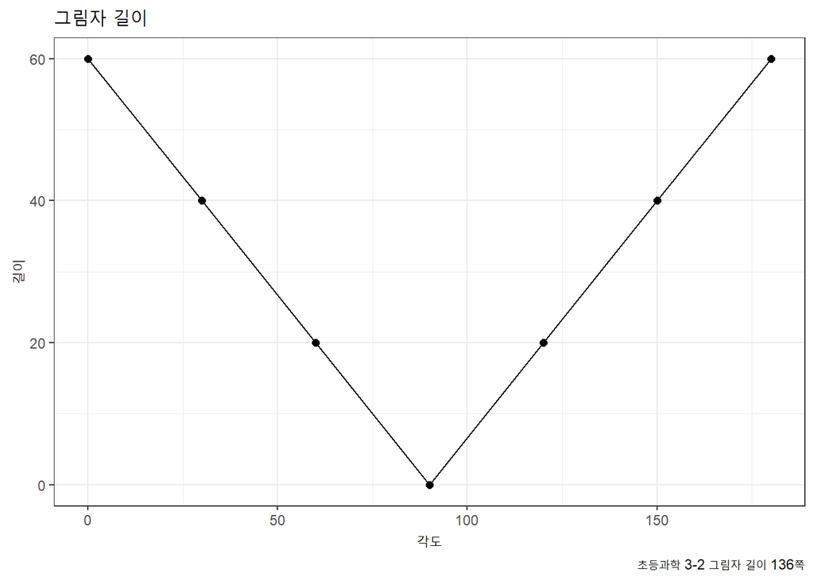

```r
shadow_length %>%
  ggplot(aes(x = 각도, y = 길이)) +
    geom_line() +
    geom_point(size = 2) +
    theme_bw(base_family = "NanumGothic") +
    labs(title = "그림자 길이",
         caption = "초등과학 3-2 그림자 길이 136쪽")
```

이와 유사한 방식으로 후속 작업을 이어가면 일일이 데이터를 찾아 `.csv` 파일로 저장하고 가져와서 필요하면 오류수정 등 불필요한 낭비되는 시간을 대폭 줄일 수 있다.

[^1]: [유충현 (2021-09-04), “한글 R 패키지 개발 이슈 및 해결 방법”](https://choonghyunryu.github.io/develop_Korean_package/)

데이터 과학자 [이광춘](https://github.com/statkclee/) 저작

*kwangchun.lee.7@gmail.com*